# Pre-Transplant Biomarkers for Graft Failure in Kidney Transplant Recipients

BIOS 668 Final Project

Amanda Robinson

# Introduction

As of May 3, 2026, there are almost 95,000 people waiting for a kidney transplant in the United States(1), nearly a quarter of which have been waiting for three or more years. Given the high demand for deceased donor kidneys, there are complex policies in place to allocate organs fairly based on medical urgency, dialysis time, and expected post-transplant survival while also maintaining equitable access to transplant for marginalized populations.

Historically, prioritizing post-transplant survival has, at times, negatively impacted access to transplant for racial minorities. Transplant recipients with fewer human leukocyte antigen (HLA) mismatches were shown to have higher post-transplant graft survival during the infancy of the national allocation system (2). As a result, early policies gave priority to candidates with a lower HLA mismatch to an available donor. However, candidates were more likely to be matches with donors to whom they are more genetically similar, which is more common when the donor and candidate are of the same race (3). African Americans are over-represented on the kidney waiting list (29%) (1) relative to their prevalence in the general population (14%)(4) as well as the deceased donor pool (14%)(5), and thus are less likely to receive priority for HLA matching.

The Organ Procurement and Transplantation Network has refined policy to place less emphasis on HLA matching in kidney allocation, but that does not address the disparity in post-transplant outcomes African American patients experience as a result of having to accept organs from less compatible donors. Little can be done in terms of changing the population dynamics of the waiting list and donor pool, but perhaps targeted treatments could be developed to close the gap in post-transplant survival across degrees of HLA matching.

The goal of this analysis is to identify biomarkers associated with graft failure in African American kidney recipients. To do so, we utilize data from single cell RNA sequencing (scRNA-seq) of pre-transplant peripheral blood mononuclear cells (PBMC) samples obtained from four African American kidney recipients, two of which experienced graft failure within three years (6).

# Methods

We obtained FASTQ files of scRNA-seq data for PBMC samples from four African American kidney transplant recipients from the Gene Expression Omnibus (GEO Accession: GSE182916)(6). Two recipients experienced graft failure within three years of transplant, while the other to received grafts that functioned for at least three years. All samples were obtained prior to transplant with the goal of identifying pre-transplant biomarkers of graft failure.

Once the data were staged for analysis, we identified the three annotated clusters with the most cells, then used the Wilcoxan rank sum test to detect differential expression of genes between the graft-failure and stable groups as measured by the SCTransformed counts. We adjusted p-values to ensure an uninflated false discovery rate using the Benjamini-Hochberg procedure. We used the Gene Ontology (GO) (13) and Kyoto Encyclopedia of Genes and Genomes (KEGG) (14) databases for functional enrichment analysis to determine the biological pathways associated with differentially expressed genes within cell types between graft-failure and stable samples using `clusterProfiler`.

Data processing was completed on the VCU high performance computing resource. All statistical analyses were performed using R 4.5.3 (15). The code for this analysis can be found on [GitHub](https://github.com/amandamrobinson/BIOS668-final-project).

# Results

## Data Processing

### Pre-Processing & Quality Control

**Table 1** summarizes the raw and filtered cell counts for each patient. Sequencing depth varied across patients, with a minimum of 2178 cells and a maximum of 5048. **Figures 1** and **2** show pre-filtering metrics for each patient. Patient 4 had notably fewer genes and molecules per cell than the other three patients, while the percentage of mitochondrial RNA was similar across samples. After filtering, the minimum number of cells per sample was 1955 and the maximum was 4725.

```r
library(tidyverse)
library(Seurat)
library(patchwork)
library(Azimuth)
library(clusterProfiler)
library(org.Hs.eg.db)
library(ggrepel)
library(knitr)
library(kableExtra)

#Some process in here is random
set.seed(12349)

# Define your data directory, patients, and their outcomes
data_dir <- paste0(getwd(), "/data/")
samples <- list.files(path = data_dir, include.dirs = TRUE)

# Function to import and format each sample as a Seurat object
format_sample <- function(smpl){

  # 1. Read the Cell Ranger directory
  data <- Read10X(data.dir = paste0(data_dir, smpl))

  # 2. Create the Seurat object
  obj <- CreateSeuratObject(counts = data, project = "KidneyTransplant")

  # 3. Add metadata: Patient ID and Outcome
  obj$patient_id <- smpl
  obj$outcome <- ifelse(str_detect(smpl, "Fail"), "Graft_Failure", "Stable")

  obj

}

# Create a list of Seurat objects
seurat_list <- map(samples, format_sample)

# 4. Merge into one combined object
pbmc <- merge(seurat_list[[1]],
              y = seurat_list[2:length(seurat_list)],
              add.cell.ids = samples)

rm(seurat_list)

sample_counts <- pbmc@meta.data %>%
  group_by(patient_id, outcome) %>%
  summarise(cell_count = n()) %>%
  mutate(percentage = (cell_count / sum(cell_count)) * 100)
```

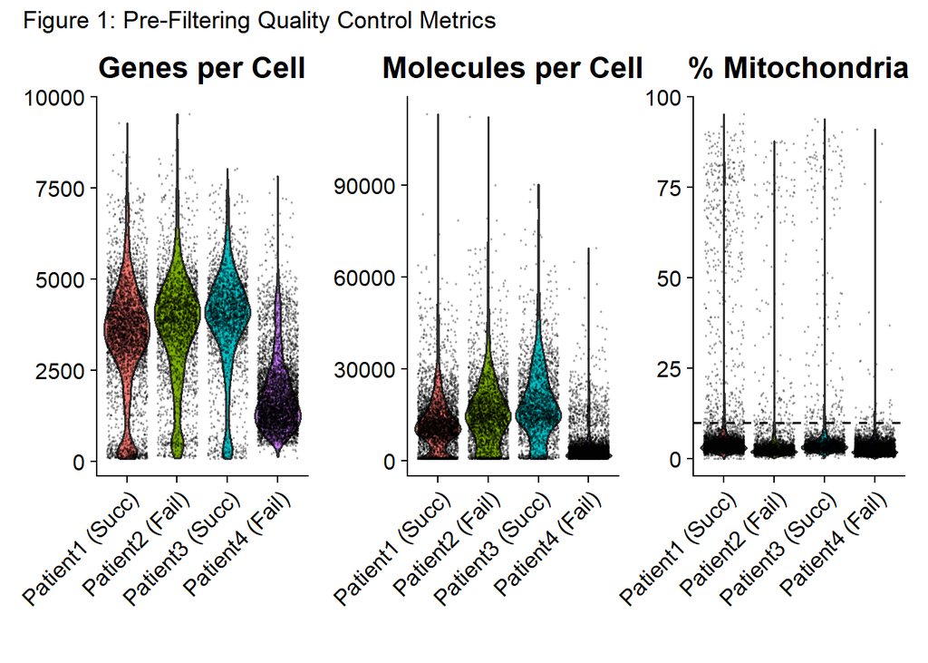

```r
fig.num <- 1

# 1. Calculate mitochondrial percentage
pbmc[["percent.mt"]] <- PercentageFeatureSet(pbmc, pattern = "^MT-")

mt_summary <- pbmc@meta.data %>%
  group_by(patient_id) %>%
  summarize(median_mt = median(percent.mt),
            mad_mt = mad(percent.mt),
            upper_limit = median_mt + (3 * mad_mt))

f_summary <- pbmc@meta.data %>%
  group_by(patient_id) %>%
  summarize(median_f = median(nFeature_RNA),
            mad_f = mad(nFeature_RNA),
            lower_limit = median_f - (3 * mad_f),
            upper_limit = median_f + (3 * mad_f))

# mt_summary
# f_summary

#Identify the max upper limit across patients to use for filtering
mt_cap <- ceiling(max(mt_summary$upper_limit))

# 2. Visualize QC metrics to decide on filtering cutoffs
vp <- VlnPlot(pbmc,
              features = c("nFeature_RNA", "nCount_RNA", "percent.mt"),
              ncol = 3,
              group.by = "patient_id",
              alpha = 0.2)

samples_clean <- paste0(str_replace(samples, "_", " ("), ")")

vp[[1]] <- vp[[1]] +
  labs(title = "Genes per Cell", x = "") +
  scale_x_discrete("", labels = samples_clean)

vp[[2]] <- vp[[2]] +
  labs(title = "Molecules per Cell", x = "") +
  scale_x_discrete("", labels = samples_clean)

vp[[3]] <- vp[[3]] +
  geom_hline(yintercept = mt_cap, linetype = "dashed") +
  labs(title = "% Mitochondria", x = "") +
  scale_x_discrete("", labels = samples_clean)

vp +
  plot_annotation(title = paste0("Figure ", fig.num,
                                 ": Pre-Filtering Quality Control Metrics"))
```

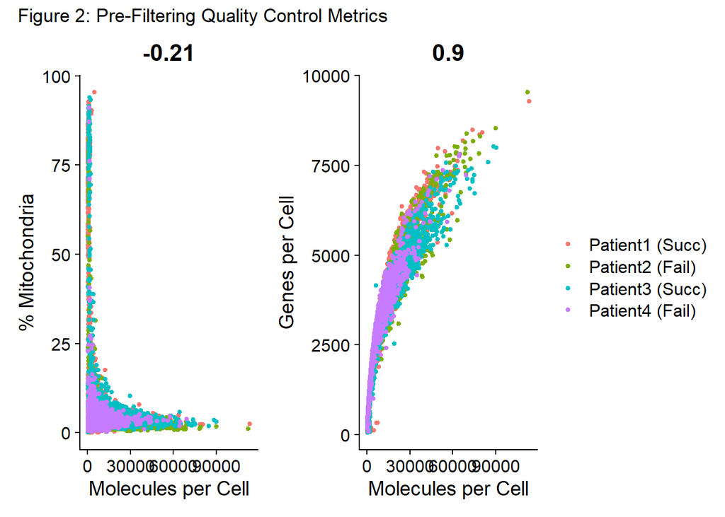

```r
fig.num <- fig.num + 1

plot1 <- FeatureScatter(pbmc, feature1 = "nCount_RNA", feature2 = "percent.mt",
                        group.by = "patient_id")
plot2 <- FeatureScatter(pbmc, feature1 = "nCount_RNA", feature2 = "nFeature_RNA",
                        group.by = "patient_id")

plot1 +
  labs(x = "Molecules per Cell",
       y = "% Mitochondria") +
  NoLegend() +
  plot2 +
  labs(x = "Molecules per Cell",
       y = "Genes per Cell") +
  scale_color_discrete("", labels = samples_clean) +
  plot_annotation(title = paste0("Figure ", fig.num,
                                 ": Pre-Filtering Quality Control Metrics"))
```

```r
tab.num <- 1
# 3. Subset data to cells with less than the calculated cap mitochondrial reads,
#    more than 200 genes detected, and fewer than the patient-specific gene cap
pbmc <- subset(pbmc,
               subset = percent.mt < mt_cap &
                          nFeature_RNA > 200 &
                          ((patient_id == samples[1] &
                              nFeature_RNA < f_summary$upper_limit[1]) |
                           (patient_id == samples[2] &
                             nFeature_RNA < f_summary$upper_limit[2]) |
                           (patient_id == samples[3] &
                             nFeature_RNA < f_summary$upper_limit[3]) |
                           (patient_id == samples[4] &
                             nFeature_RNA < f_summary$upper_limit[4])))

filter_counts <- pbmc@meta.data %>%
  group_by(patient_id, outcome) %>%
  summarise(cell_count = n()) %>%
  mutate(percentage = (cell_count / sum(cell_count)) * 100)

sample_counts %>%
  left_join(filter_counts, by = c("patient_id", "outcome")) %>%
  mutate(patient_id = str_remove(patient_id, "_[A-Za-z]+"),
         outcome = str_replace(outcome, "_", " ")) %>%
  dplyr::select(-contains("percentage")) %>%
  kable(col.names = c("Patient", "Outcome", "Raw N", "Filtered N"),
        caption = paste0("Table ", tab.num,
                         ": Raw and Filtered Cell Counts by Patient")) %>%
  kable_styling()
```

Table 1: Raw and Filtered Cell Counts by Patient

| Patient | Outcome | Raw N | Filtered N |
| --- | --- | --- | --- |
| Patient1 | Stable | 3820 | 3242 |
| Patient2 | Graft Failure | 2645 | 2451 |
| Patient3 | Stable | 2178 | 1955 |
| Patient4 | Graft Failure | 5048 | 4725 |

### Normalization

```r
pbmc <- SCTransform(pbmc,
                    vars.to.regress = "percent.mt",
                    verbose = FALSE)
```

### Data Reduction

**Figure 3** shows the ranked standard deviation for the first 20 principal components. The plot levels off around the 15th principal component, which motivated our decision to use the first 15 principal components for clustering.

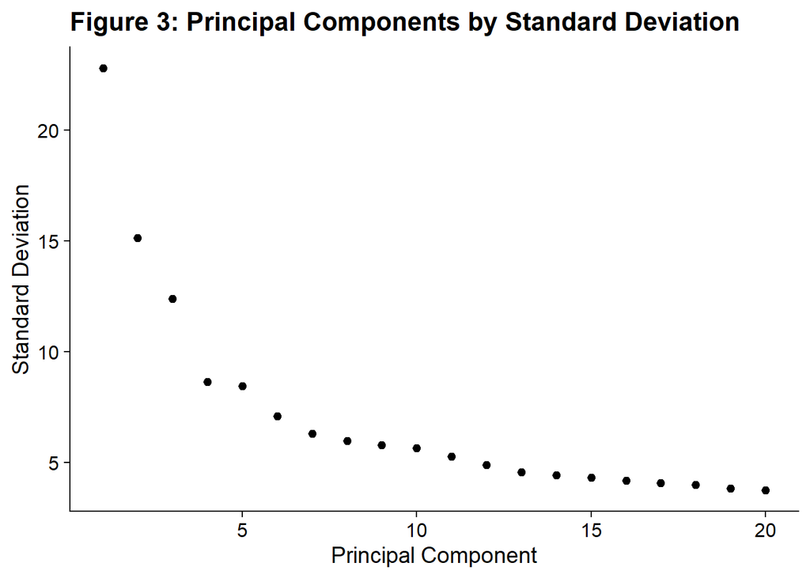

```r
fig.num <- fig.num + 1

pbmc <- RunPCA(pbmc, assay = "SCT")

# Run this to see the elbow for your data
ElbowPlot(pbmc) +
  labs(title = paste0("Figure ", fig.num,
                      ": Principal Components by Standard Deviation"),
       x = "Principal Component")
```

### Data Integration and Clustering

**Figure 4** shows cells by the first two pre-integration UMAP dimensions, patient, and cluster. In general, cells from different samples are not well integrated.

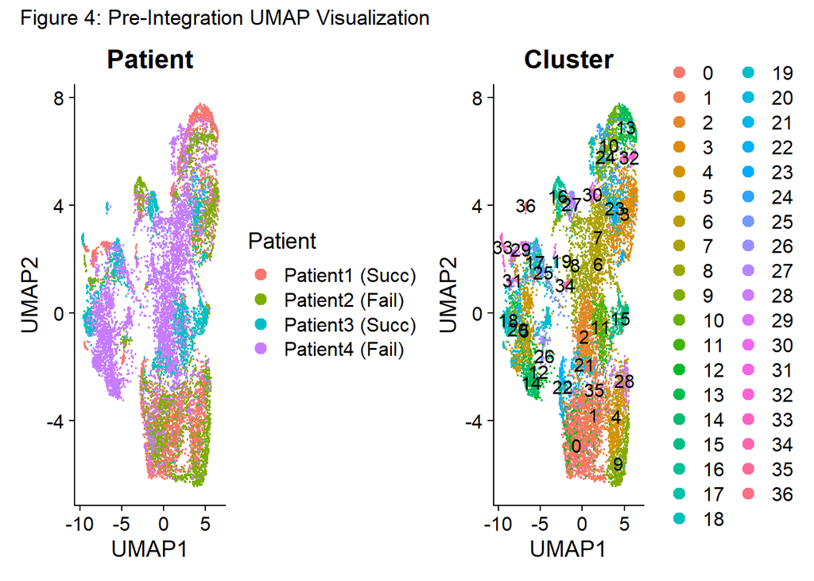

```r
fig.num <- fig.num + 1

pbmc <- FindNeighbors(pbmc, dims = 1:15, reduction = "pca")
pbmc <- FindClusters(pbmc, resolution = 2, verbose = FALSE)
pbmc <- RunUMAP(pbmc, dims = 1:15, reduction = "pca",
                reduction.name = "umap.unintegrated")

# 1. Create the Patient UMAP with your custom labels
p1 <- DimPlot(pbmc, reduction = "umap.unintegrated", group.by = "patient_id") +
  scale_color_discrete(name = "Patient", labels = samples_clean) +
  labs(title = "Patient",
       x = "UMAP1",
       y = "UMAP2") +
  theme(legend.position = "right")

# 2. Create the Cluster UMAP
p2 <- DimPlot(pbmc, reduction = "umap.unintegrated",
              group.by = "seurat_clusters", label = TRUE) +
  labs(title = "Cluster",
       x = "UMAP1",
       y = "UMAP2") +
  theme(legend.position = "right")

(p1 | p2) +
  plot_annotation(title = paste0("Figure ", fig.num,
                                 ": Pre-Integration UMAP Visualization"))
```

**Figure 5** shows cells by the first two post-integration UMAP dimensions, patient, and cluster. In general, the cells from each patient were not separable from the cells from other patients. The patients were much better integrated, and 21 clusters were identified.

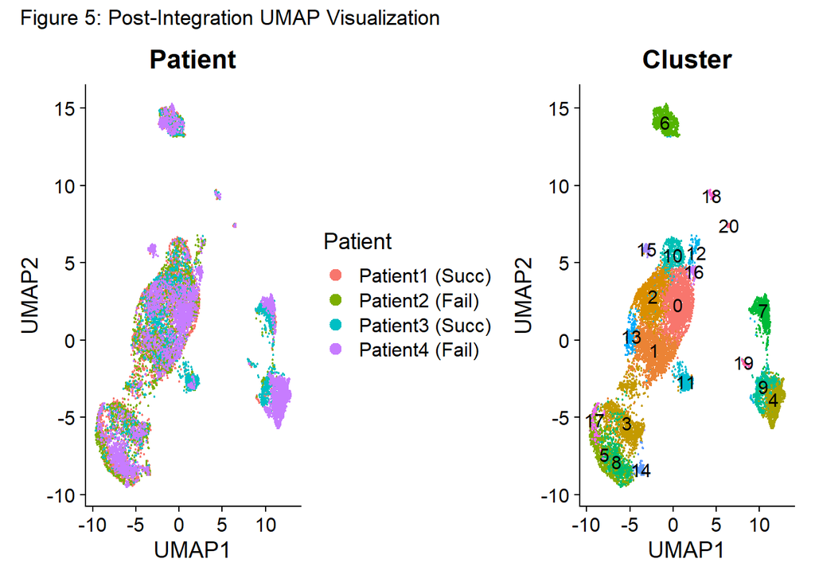

```r
fig.num <- fig.num + 1

pbmc <- IntegrateLayers(object = pbmc,
                        method = HarmonyIntegration,
                        orig.reduction = "pca",
                        new.reduction = "integrated.harmony",
                        verbose = FALSE)

# re-join layers after integration
# pbmc[["SCT"]] <- JoinLayers(pbmc[["SCT"]])

pbmc <- FindNeighbors(pbmc, reduction = "integrated.harmony", dims = 1:15)
pbmc <- FindClusters(pbmc, resolution = 0.8, verbose = FALSE)
pbmc <- RunUMAP(pbmc, dims = 1:15, reduction = "integrated.harmony",
                reduction.name = "umap.harmony")

# 1. Create the Patient UMAP with your custom labels
p1 <- DimPlot(pbmc, reduction = "umap.harmony", group.by = "patient_id") +
  scale_color_discrete(name = "Patient", labels = samples_clean) +
  labs(title = "Patient",
       x = "UMAP1",
       y = "UMAP2") +
  theme(legend.position = "right")

# 2. Create the Cluster UMAP
p2 <- DimPlot(pbmc, reduction = "umap.harmony",
              group.by = "seurat_clusters", label = TRUE) +
  labs(title = "Cluster",
       x = "UMAP1",
       y = "UMAP2") +
  theme(legend.position = "right")

(p1 | p2 + NoLegend()) +
  plot_annotation(title = paste0("Figure ", fig.num,
                                 ": Post-Integration UMAP Visualization"))
```

### Annotation

**Figure 6** shows consensus cell type annotation for the post-integration cell clusters. We identified 10 cell types.

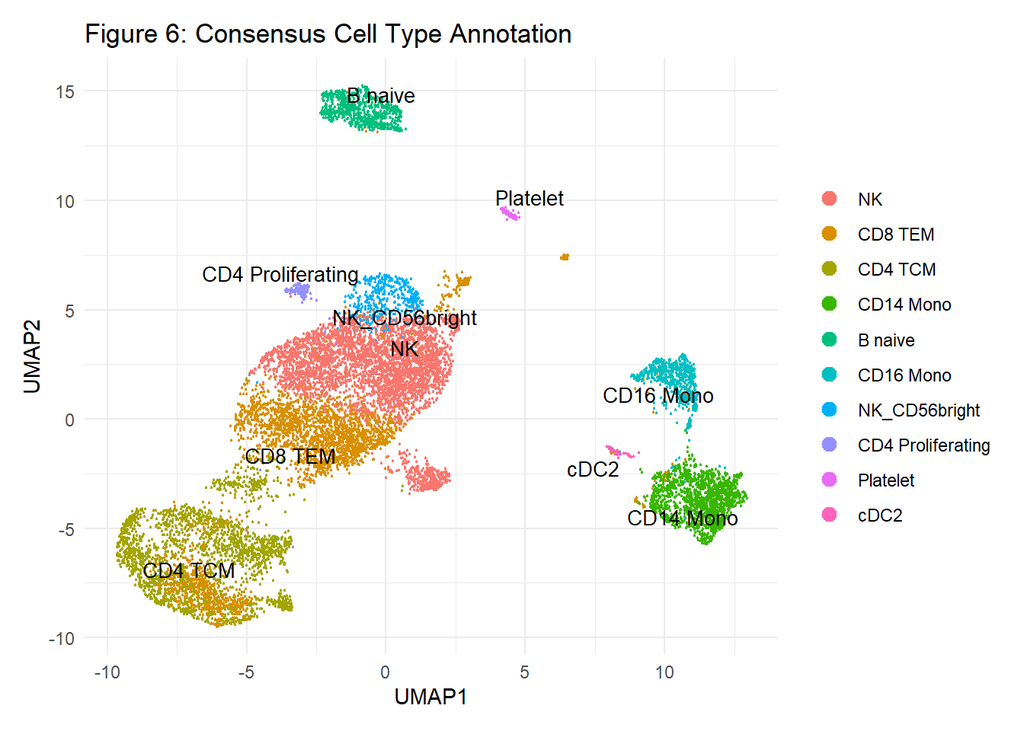

```r
fig.num <- fig.num + 1
## Final Annotation and Consensus Consolidation

# 1. Run the Azimuth Mapping engine
pbmc <- RunAzimuth(pbmc, reference = "pbmcref")

# 2. Ensure we are looking at the CLUSTERS before renaming
# This is the "Safety Reset"
Idents(pbmc) <- "seurat_clusters"

# 3. Generate the Consensus Labels (The "Majority Vote")
target_labels <- pbmc@meta.data %>%
  group_by(seurat_clusters) %>%
  # We filter for high-confidence predictions to avoid 'salt and pepper' noise
  filter(predicted.celltype.l2.score > 0.5) %>%
  count(predicted.celltype.l2, wt = predicted.celltype.l2.score) %>%
  slice_max(n = 1, order_by = n, with_ties = FALSE) %>%
  ungroup()

# 4. Create the mapping vector (Explicitly ensure they are characters)
annotation_map <- as.character(target_labels$predicted.celltype.l2)
names(annotation_map) <- as.character(target_labels$seurat_clusters)

# 5. Apply the rename
# Since we ran Idents(pbmc) <- "seurat_clusters", it WILL find them now
pbmc <- RenameIdents(pbmc, annotation_map)
#
# # 6. Save the result
pbmc$cell_type <- Idents(pbmc)

# 7. Final Visualization
DimPlot(pbmc, reduction = "umap.harmony", label = TRUE, label.size = 3.5,
        repel = TRUE) +
  theme_minimal() +
  labs(title = paste0("Figure ", fig.num, ": Consensus Cell Type Annotation")) +
  labs(x = "UMAP1",
       y = "UMAP2")
```

## Differential Expression

**Table 2** and **Figure 7** show consensus annotated cell type by graft function. NK, CD8 TEM, and CD4 TCM cells were the most common overall. CD8 TEM cells were more often from patients whit graft failure (63%) than those with stable grafts.

```r
tab.num <- tab.num + 1

# 1. Create the data frame from your 6 cell types
# Note: Ensure 'cell_type' is the column with your 6 consensus labels
df <- as.data.frame(table(pbmc$outcome, pbmc$cell_type))
colnames(df) <- c("Outcome", "CellType", "Count")

# 2. Calculate proportions so the bars are all the same height (100%)
df <- df %>%
  group_by(CellType) %>%
  mutate(Proportion = Count / sum(Count)) %>%
  ungroup()

top3 <- df %>%
  group_by(CellType) %>%
  summarise(n = sum(Count)) %>%
  arrange(desc(n)) %>%
  dplyr::slice(1:3) %>%
  .$CellType %>%
  as.character()

df %>%
  mutate(n_pct = paste0(Count, " (", round(100 * Proportion, 2), "%)"),
         CellType = str_replace(CellType, "_", " ")) %>%
  dplyr::select(Outcome, CellType, n_pct) %>%
  pivot_wider(names_from = Outcome, values_from = n_pct) %>%
  kable(col.names = c("Cell Type", "Graft Failure", "Stable"),
        caption = paste0("Table ", tab.num,
                         ": N (%) Consensus Annotated Cell Type by Graft Function")) %>%
  kable_styling()
```

Table 2: N (%) Consensus Annotated Cell Type by Graft Function

| Cell Type | Graft Failure | Stable |
| --- | --- | --- |
| NK | 1994 (52.38%) | 1813 (47.62%) |
| CD8 TEM | 1745 (63.25%) | 1014 (36.75%) |
| CD4 TCM | 1144 (51.44%) | 1080 (48.56%) |
| CD14 Mono | 1195 (81.57%) | 270 (18.43%) |
| B naive | 472 (62.02%) | 289 (37.98%) |
| CD16 Mono | 296 (44.58%) | 368 (55.42%) |
| NK CD56bright | 144 (34.53%) | 273 (65.47%) |
| CD4 Proliferating | 116 (94.31%) | 7 (5.69%) |
| Platelet | 58 (68.24%) | 27 (31.76%) |
| cDC2 | 12 (17.65%) | 56 (82.35%) |

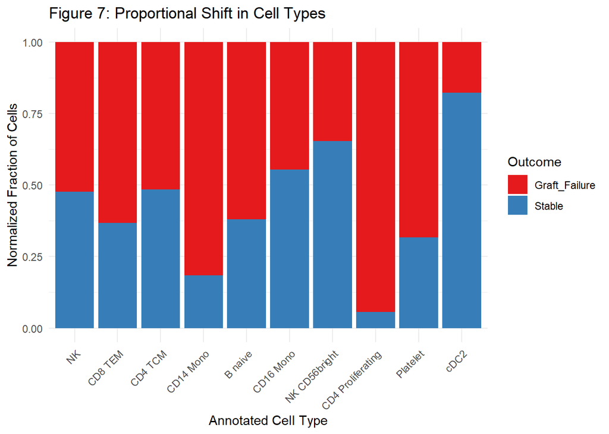

```r
fig.num <- fig.num + 1

cell_type <- str_replace(levels(df$CellType), "_", " ")

# 3. Plot with the corrected theme syntax
ggplot(df, aes(x = CellType, y = Proportion, fill = Outcome)) +
  geom_bar(stat = "identity", position = "stack") +
  theme_minimal() +
  scale_fill_manual(values = c("Graft_Failure" = "#E41A1C",
                               "Stable" = "#377EB8")) +
  scale_x_discrete(labels = cell_type) +
  labs(title = paste0("Figure ", fig.num,
                      ": Proportional Shift in Cell Types"),
       y = "Normalized Fraction of Cells",
       x = "Annotated Cell Type") +
  theme(axis.text.x = element_text(angle = 45, vjust = 1, hjust = 1))
```

**Table 3** and **Figure 8** show differential expression results by cell type. FKBP5, NEAT1, and CRYBG1 were upregulated across cell types.

```r
tab.num <- tab.num + 1
pval_threshold <- 0.05
fc_threshold <- 1
state <- levels(factor(pbmc@meta.data$outcome))

pbmc <- PrepSCTFindMarkers(pbmc)

pbmc@meta.data <- pbmc@meta.data %>%
  mutate(cell_function = paste0(cell_type, "_", outcome))

Idents(pbmc) <- "cell_function"

get_de_results <- function(ct){

  g <- paste0(ct, "_", state)

  fm <- FindMarkers(pbmc,
                    ident.1 = g[1],
                    ident.2 = g[2],
                    verbose = FALSE,
                    p.adjust.method = "BH")

  fm %>%
    rownames_to_column("label") %>%
    mutate(entrez = mapIds(org.Hs.eg.db,
                           keys = label,
                           column = 'ENTREZID',
                           keytype = 'SYMBOL',
                           multiVals = "first"),
           cell_type = ct,
           neg_log10_p = -log10(ifelse(p_val_adj == 0, 1e-300, p_val_adj)),
           status = case_when(p_val_adj < pval_threshold &
                                avg_log2FC >= fc_threshold ~ "Upregulated",
                              p_val_adj < pval_threshold &
                                avg_log2FC <= -fc_threshold ~ "Downregulated",
                              TRUE ~ "Not Significant"))

}

de_results <- map_df(top3, get_de_results)

de_results %>%
  group_by(cell_type) %>%
  mutate(rn = row_number(),
         p_val_adj = format.pval(p_val_adj, eps = 0.001),
         avg_log2FC = round(avg_log2FC, 2),
         pct.1 = round(100 * pct.1, 2),
         pct.2 = round(100 * pct.2, 2)) %>%
  filter(rn <= 5) %>%
  dplyr::select(cell_type, label, avg_log2FC, pct.1, pct.2, p_val_adj,
                status) %>%
  kable(col.names = c("Cell Type", "Gene", "Average LogFC",
                      "% Cells w/ Gene in Graft Failure",
                      "% Cells w/ Gene in Stable", "Adjusted p-value",
                      "Regulation"),
        caption = paste0("Table ", tab.num,
                         ": Top 5 Genes Differentially Expressed in Graft Failure vs Stable Cells by Cell Type")) %>%
  kable_styling() %>%
  collapse_rows(columns = 1)
```

Table 3: Top 5 Genes Differentially Expressed in Graft Failure vs Stable Cells by Cell Type

| Cell Type | Gene | Average LogFC | % Cells w/ Gene in Graft Failure | % Cells w/ Gene in Stable | Adjusted p-value | Regulation |
| --- | --- | --- | --- | --- | --- | --- |
| NK | FKBP5 | 2.83 | 90.7 | 24.7 | < 0.001 | Upregulated |
|  | NEAT1 | 1.73 | 99.4 | 77.4 | < 0.001 | Upregulated |
|  | CCL5 | -2.17 | 53.7 | 87.4 | < 0.001 | Downregulated |
|  | XIST | -10.49 | 0.0 | 43.2 | < 0.001 | Downregulated |
|  | CRYBG1 | 1.72 | 80.7 | 29.4 | < 0.001 | Upregulated |
| CD8 TEM | NEAT1 | 1.84 | 98.5 | 71.0 | < 0.001 | Upregulated |
|  | FKBP5 | 2.28 | 93.1 | 36.8 | < 0.001 | Upregulated |
|  | XIST | -10.00 | 0.0 | 41.0 | < 0.001 | Downregulated |
|  | CCL5 | -2.02 | 48.8 | 83.6 | < 0.001 | Downregulated |
|  | CRYBG1 | 1.59 | 86.8 | 43.9 | < 0.001 | Upregulated |
| CD4 TCM | NEAT1 | 2.30 | 83.0 | 44.6 | < 0.001 | Upregulated |
|  | CRYBG1 | 1.48 | 93.7 | 60.6 | < 0.001 | Upregulated |
|  | RPS4Y1 | 2.18 | 70.3 | 16.6 | < 0.001 | Upregulated |
|  | UBASH3B | 2.29 | 69.1 | 22.5 | < 0.001 | Upregulated |
|  | FKBP5 | 1.29 | 95.4 | 71.0 | < 0.001 | Upregulated |

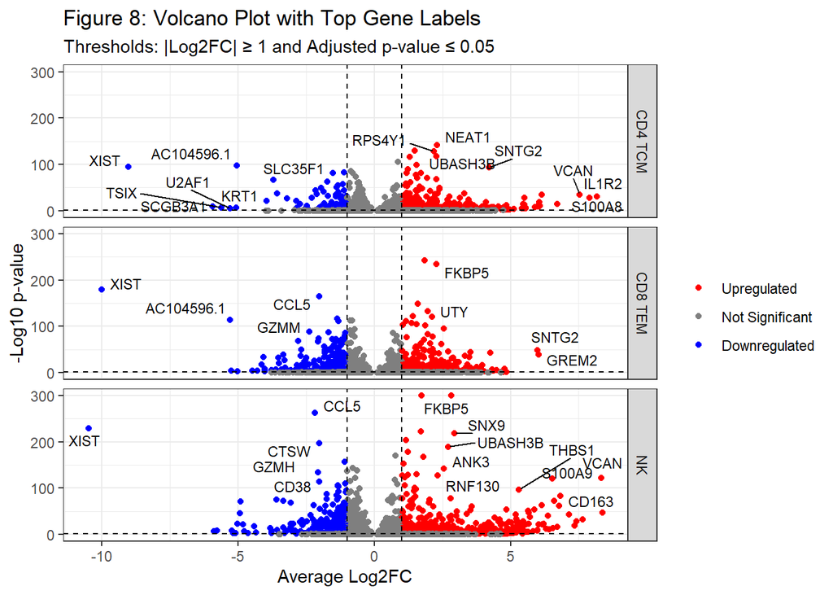

```r
fig.num <- fig.num + 1

de_results %>%
  group_by(cell_type) %>%
  # Only create a label for genes that are significant AND high fold change
  mutate(label_subset = ifelse(p_val_adj < 0.001 & abs(avg_log2FC) > 2, label,
                               "")) %>%
  ggplot() +
  geom_point(aes(x = avg_log2FC, y = neg_log10_p, color = fct_rev(status))) +
  scale_color_manual(values = c("Upregulated" = "red",
                                "Downregulated" = "blue",
                                "Not Significant" = "grey50")) +
  # Add threshold lines
  geom_vline(xintercept = c(-fc_threshold, fc_threshold),
             linetype = "dashed", color = "black", linewidth = 0.5) +
  geom_hline(yintercept = -log10(pval_threshold),
             linetype = "dashed", color = "black", linewidth = 0.5) +
  #TO DO: panel-specific labels
  geom_text_repel(aes(x = avg_log2FC, y = neg_log10_p, label = label_subset),
                  size = 3, max.overlaps = 15) +
  labs(title = paste0("Figure ", fig.num,
                      ": Volcano Plot with Top Gene Labels"),
       subtitle = paste0("Thresholds: |Log2FC| \u2265 ", fc_threshold,
                         " and Adjusted p-value \u2264 ", pval_threshold),
       x = "Average Log2FC",
       y = "-Log10 p-value",
       color = "") +
  theme_bw() +
  facet_wrap(~cell_type, nrow = 3, strip.position = "right")
```

## Functional Enrichment

**Figure 9** and **Table 4** show the results of the GO functional enrichment analysis by cell type. Roughly 10% of differentially expressed genes in NK and CD8 TEM cells were associated with cell-cell adhesion, and roughly 9% of differentially expressed genes in CD4 TCM were associated with inflammatory response.

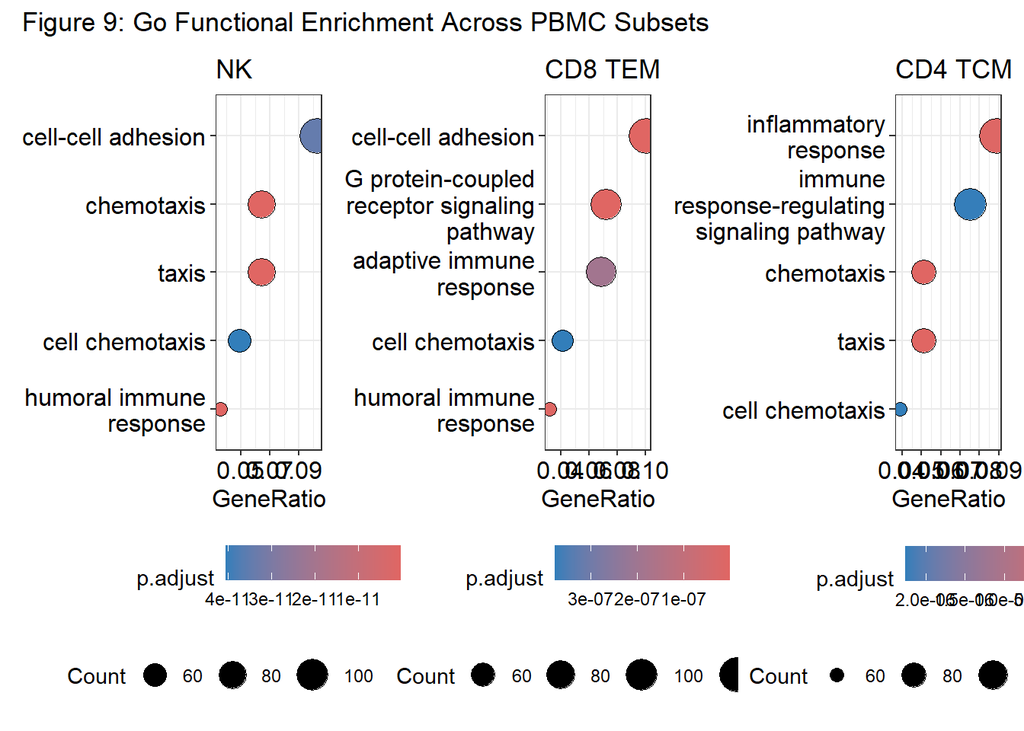

```r
fig.num <- fig.num + 1

get_go_enrichment <- function(ct){

  ct_df <- de_results %>%
    filter(cell_type == ct)

  genes <- ct_df %>%
  filter(abs(avg_log2FC) > 1) %>%
  .$entrez

  ego <- enrichGO(gene = genes,
                  universe = ct_df$entrez,
                  OrgDb = org.Hs.eg.db,
                  ont = "BP",
                  pAdjustMethod = "BH",
                  pvalueCutoff = 0.01,
                  qvalueCutoff = 0.05,
                  readable = TRUE)

  head(ego, n = 10) %>%
    mutate(cell_type = ct,
           ego = list(ego))

}

go_results <- map_df(top3, get_go_enrichment)

# Assuming you saved your enrichment objects in a list
plot_list <- map2(unique(go_results$ego), unique(go_results$cell_type),
                  ~dotplot(.x, showCategory = 5)+
                    labs(title = .y) +
                    theme(legend.position = "bottom",
                          legend.box = "vertical") +
                    scale_y_discrete(labels = function(x) str_wrap(x,
                                                                   width = 20)))

# Wrap them into a 1x3 grid
wrap_plots(plot_list, nrow = 1) +
  plot_annotation(title = paste0("Figure ", fig.num,
                                 ": Go Functional Enrichment Across PBMC Subsets"))
```

```r
tab.num <- tab.num + 1

go_results %>%
  dplyr::select(cell_type, ID, Description, GeneRatio, BgRatio, FoldEnrichment,
                p.adjust) %>%
  mutate(FoldEnrichment = round(FoldEnrichment, 2),
         p.adjust = format.pval(p.adjust, eps = 0.001)) %>%
  kable(col.names = c("Cell Type", "GO ID", "Biological Process", "Gene Ratio",
                      "Background Gene Ratio", "Fold Enrichment",
                      "Adjusted p-value"),
        caption = paste0("Table ", tab.num,
                         ": GO Functional Gene Enrichment by Cell Type"),
        row.names = FALSE) %>%
  kable_styling() %>%
  collapse_rows(columns = 1)
```

Table 4: GO Functional Gene Enrichment by Cell Type

| Cell Type | GO ID | Biological Process | Gene Ratio | Background Gene Ratio | Fold Enrichment | Adjusted p-value |
| --- | --- | --- | --- | --- | --- | --- |
| NK | GO:0006935 | chemotaxis | 80/1246 | 201/7818 | 2.50 | < 0.001 |
|  | GO:0042330 | taxis | 80/1246 | 201/7818 | 2.50 | < 0.001 |
|  | GO:0006959 | humoral immune response | 45/1246 | 81/7818 | 3.49 | < 0.001 |
|  | GO:0098609 | cell-cell adhesion | 128/1246 | 425/7818 | 1.89 | < 0.001 |
|  | GO:0060326 | cell chemotaxis | 61/1246 | 146/7818 | 2.62 | < 0.001 |
|  | GO:0007186 | G protein-coupled receptor signaling pathway | 88/1246 | 263/7818 | 2.10 | < 0.001 |
|  | GO:0050900 | leukocyte migration | 71/1246 | 196/7818 | 2.27 | < 0.001 |
|  | GO:0006954 | inflammatory response | 122/1246 | 419/7818 | 1.83 | < 0.001 |
|  | GO:0071345 | cellular response to cytokine stimulus | 132/1246 | 467/7818 | 1.77 | < 0.001 |
|  | GO:0019221 | cytokine-mediated signaling pathway | 90/1246 | 279/7818 | 2.02 | < 0.001 |
| CD8 TEM | GO:0098609 | cell-cell adhesion | 129/1286 | 430/7958 | 1.86 | < 0.001 |
|  | GO:0007186 | G protein-coupled receptor signaling pathway | 92/1286 | 271/7958 | 2.10 | < 0.001 |
|  | GO:0006959 | humoral immune response | 41/1286 | 85/7958 | 2.98 | < 0.001 |
|  | GO:0002250 | adaptive immune response | 88/1286 | 284/7958 | 1.92 | < 0.001 |
|  | GO:0060326 | cell chemotaxis | 53/1286 | 142/7958 | 2.31 | < 0.001 |
|  | GO:0006935 | chemotaxis | 67/1286 | 199/7958 | 2.08 | < 0.001 |
|  | GO:0042330 | taxis | 67/1286 | 199/7958 | 2.08 | < 0.001 |
|  | GO:0006954 | inflammatory response | 114/1286 | 412/7958 | 1.71 | < 0.001 |
|  | GO:0008284 | positive regulation of cell population proliferation | 115/1286 | 419/7958 | 1.70 | < 0.001 |
|  | GO:0050865 | regulation of cell activation | 100/1286 | 359/7958 | 1.72 | < 0.001 |
| CD4 TCM | GO:0006935 | chemotaxis | 79/1542 | 199/7937 | 2.04 | < 0.001 |
|  | GO:0042330 | taxis | 79/1542 | 199/7937 | 2.04 | < 0.001 |
|  | GO:0006954 | inflammatory response | 137/1542 | 423/7937 | 1.67 | < 0.001 |
|  | GO:0002764 | immune response-regulating signaling pathway | 116/1542 | 359/7937 | 1.66 | < 0.001 |
|  | GO:0060326 | cell chemotaxis | 60/1542 | 149/7937 | 2.07 | < 0.001 |
|  | GO:0050900 | leukocyte migration | 72/1542 | 195/7937 | 1.90 | < 0.001 |
|  | GO:0098657 | import into cell | 141/1542 | 468/7937 | 1.55 | < 0.001 |
|  | GO:0032103 | positive regulation of response to external stimulus | 116/1542 | 371/7937 | 1.61 | < 0.001 |
|  | GO:0030595 | leukocyte chemotaxis | 48/1542 | 115/7937 | 2.15 | < 0.001 |
|  | GO:0043299 | leukocyte degranulation | 28/1542 | 52/7937 | 2.77 | < 0.001 |

**Figure 10** and **Table 5** show the results of the KEGG functional enrichment analysis by cell type. The largest proportion of differentially expressed genes were associated with cytokine-cytokine receptor interactions for NK (9%), CD8 TEM (7%), and CD4 TCM cells (5%).

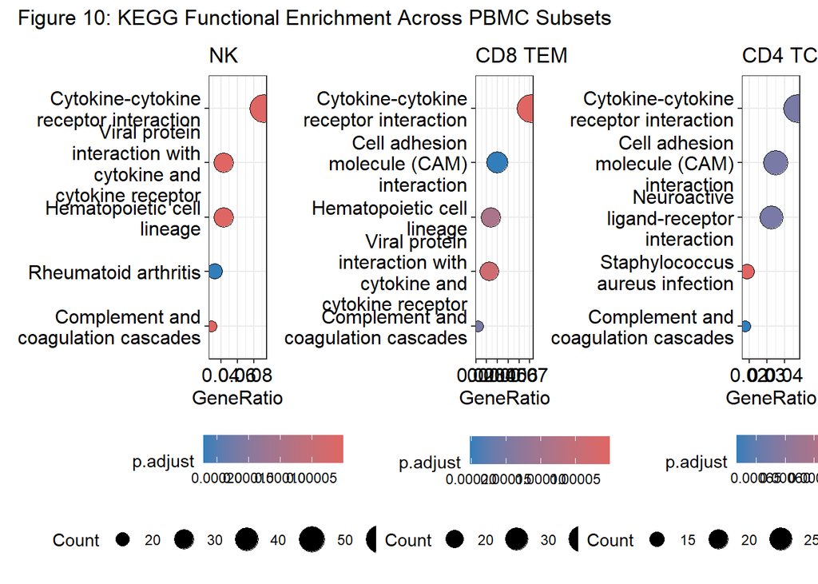

```r
fig.num <- fig.num + 1

get_kegg_enrichment <- function(ct){

  ct_df <- de_results %>%
    filter(cell_type == ct)

  genes <- ct_df %>%
  filter(abs(avg_log2FC) > 1) %>%
  .$entrez

  kk <- enrichKEGG(gene = genes,
                   universe = ct_df$entrez,
                   organism = "hsa",
                   pAdjustMethod = "BH",
                   pvalueCutoff = 0.01,
                   qvalueCutoff = 0.05)

  head(kk, n = 10) %>%
    mutate(cell_type = ct,
           kk = list(kk))

}

kegg_results <- map_df(top3, get_kegg_enrichment)

# Assuming you saved your enrichment objects in a list
plot_list <- map2(unique(kegg_results$kk), unique(kegg_results$cell_type),
                  ~dotplot(.x, showCategory = 5)+
                    labs(title = .y) +
                    theme(legend.position = "bottom",
                          legend.box = "vertical") +
                    scale_y_discrete(labels = function(x) str_wrap(x,
                                                                   width = 20)))

# Wrap them into a 1x3 grid
wrap_plots(plot_list, nrow = 1) +
  plot_annotation(title = paste0("Figure ", fig.num,
                                 ": KEGG Functional Enrichment Across PBMC Subsets"))
```

```r
tab.num <- tab.num + 1

kegg_results %>%
  dplyr::select(cell_type, ID, Description, GeneRatio, BgRatio, FoldEnrichment,
                p.adjust) %>%
  mutate(FoldEnrichment = round(FoldEnrichment, 2),
         p.adjust = format.pval(p.adjust, eps = 0.001)) %>%
  kable(col.names = c("Cell Type", "KEGG ID", "Description", "Gene Ratio",
                      "Background Gene Ratio", "Fold Enrichment",
                      "Adjusted p-value"),
        caption = paste0("Table ", tab.num,
                         ": KEGG Functional Gene Enrichment by Cell Type"),
        row.names = FALSE) %>%
  kable_styling() %>%
  collapse_rows(columns = 1)
```

Table 5: KEGG Functional Gene Enrichment by Cell Type

| Cell Type | KEGG ID | Description | Gene Ratio | Background Gene Ratio | Fold Enrichment | Adjusted p-value |
| --- | --- | --- | --- | --- | --- | --- |
| NK | hsa04060 | Cytokine-cytokine receptor interaction | 62/671 | 101/3889 | 3.56 | < 0.001 |
|  | hsa04061 | Viral protein interaction with cytokine and cytokine receptor | 29/671 | 43/3889 | 3.91 | < 0.001 |
|  | hsa04640 | Hematopoietic cell lineage | 29/671 | 49/3889 | 3.43 | < 0.001 |
|  | hsa04610 | Complement and coagulation cascades | 19/671 | 26/3889 | 4.24 | < 0.001 |
|  | hsa05323 | Rheumatoid arthritis | 22/671 | 48/3889 | 2.66 | < 0.001 |
|  | hsa04514 | Cell adhesion molecule (CAM) interaction | 26/671 | 64/3889 | 2.35 | < 0.001 |
|  | hsa04080 | Neuroactive ligand-receptor interaction | 22/671 | 52/3889 | 2.45 | < 0.001 |
|  | hsa05150 | Staphylococcus aureus infection | 14/671 | 26/3889 | 3.12 | < 0.001 |
|  | hsa04974 | Protein digestion and absorption | 12/671 | 22/3889 | 3.16 | 0.0023511 |
|  | hsa05144 | Malaria | 12/671 | 22/3889 | 3.16 | 0.0023511 |
| CD8 TEM | hsa04060 | Cytokine-cytokine receptor interaction | 48/678 | 103/3914 | 2.69 | < 0.001 |
|  | hsa04061 | Viral protein interaction with cytokine and cytokine receptor | 22/678 | 42/3914 | 3.02 | < 0.001 |
|  | hsa04640 | Hematopoietic cell lineage | 23/678 | 48/3914 | 2.77 | < 0.001 |
|  | hsa04610 | Complement and coagulation cascades | 15/678 | 25/3914 | 3.46 | < 0.001 |
|  | hsa04514 | Cell adhesion molecule (CAM) interaction | 27/678 | 65/3914 | 2.40 | < 0.001 |
|  | hsa05144 | Malaria | 15/678 | 26/3914 | 3.33 | < 0.001 |
|  | hsa05323 | Rheumatoid arthritis | 21/678 | 49/3914 | 2.47 | 0.0010327 |
|  | hsa04820 | Cytoskeleton in muscle cells | 27/678 | 80/3914 | 1.95 | 0.0089361 |
|  | hsa04512 | ECM-receptor interaction | 11/678 | 21/3914 | 3.02 | 0.0089361 |
|  | hsa04814 | Motor proteins | 30/678 | 94/3914 | 1.84 | 0.0099492 |
| CD4 TCM | hsa05150 | Staphylococcus aureus infection | 15/803 | 22/3971 | 3.37 | < 0.001 |
|  | hsa04060 | Cytokine-cytokine receptor interaction | 38/803 | 95/3971 | 1.98 | < 0.001 |
|  | hsa04514 | Cell adhesion molecule (CAM) interaction | 28/803 | 62/3971 | 2.23 | < 0.001 |
|  | hsa04080 | Neuroactive ligand-receptor interaction | 26/803 | 56/3971 | 2.30 | < 0.001 |
|  | hsa04610 | Complement and coagulation cascades | 14/803 | 22/3971 | 3.15 | < 0.001 |
|  | hsa05144 | Malaria | 14/803 | 24/3971 | 2.88 | 0.0023202 |
|  | hsa04640 | Hematopoietic cell lineage | 20/803 | 43/3971 | 2.30 | 0.0038988 |

# Discussion

We identified significant upregulation genes related to inflammatory response, stress, and immune activation in NK, CD8 TEM, and CD4 TCM cells from samples obtained from patients who experiences graft failure within three years of transplant relative to those who did not. Our results align with those of Zhang and colleagues, with the notable absence of significantly different expression of IFNG found in their study. This is likely a result of the data driven decisions regarding data processing and quality control made in this study due to limited biological expertise.

There are several limitations to this analysis. Firstly, we did not have access to APOL1 genotyping. APOL1 risk alleles are most prevalent in individuals of West African decent, and they are associated with etiologically differences in kidney disease. Additionally, a sample of four individuals greatly limits the generalizability of our results to a larger population.

# References

1.

Organ Procurement and Transplantation Network (OPTN). Custom data report: Current US waiting list by waiting time and race/ethnicity [internet] [Internet]. OPTN Custom Report Builder; U.S. Department of Health; Human Services; 2026. Available from: https://optn.transplant.hrsa.gov/data/view-data-reports/build-advanced-report/

2.

CICCIARELLI J, TERASAKI PI, MICKEY MR. The effect of zero HLA class i and II mismatching in cyclosporine-treated kidney transplant patients. Transplantation. 1987;43(5):636–40.

3.

Beatty PG, Mori M, Milford E. Impact of racial genetic polymorphism on the probability of finding an HLA-matched donor. Transplantation. 1995;60(8):778–83.

4.

U.S. Census Bureau. QuickFacts: United states [internet] [Internet]. Census.gov; U.S. Department of Commerce; 2026. Available from: https://www.census.gov/quickfacts/fact/table/US/PST045223

5.

Organ Procurement and Transplantation Network (OPTN). Custom data report: Deceased donors by race/ethnicity [internet] [Internet]. OPTN Custom Report Builder; U.S. Department of Health; Human Services; 2026. Available from: https://optn.transplant.hrsa.gov/data/view-data-reports/build-advanced-report/

6.

Zhang Z, Sun Z, Fu J, Lin Q, Banu K, Chauhan K, et al. Recipient APOL1 risk alleles associate with death-censored renal allograft survival and rejection episodes. The Journal of Clinical Investigation. 2021;131(22).

7.

10x Genomics. Cell ranger [Internet]. 10x Genomics; 2026. Available from: https://www.10xgenomics.com/support/software/cell-ranger/latest/release-notes/cr-release-notes

8.

Hafemeister C, Satija R. Normalization and variance stabilization of single-cell RNA-seq data using regularized negative binomial regression. Genome biology. 2019;20(1):296.

9.

Korsunsky I, Millard N, Fan J, Slowikowski K, Zhang F, Wei K, et al. Fast, sensitive and accurate integration of single-cell data with harmony. Nature methods. 2019;16(12):1289–96.

10.

McInnes L, Healy J, Melville J. Umap: Uniform manifold approximation and projection for dimension reduction. arXiv preprint arXiv:180203426. 2018;

11.

Yu G, Wang LG, Han Y, He QY. [clusterProfiler: An r package for comparing biological themes among gene clusters](https://doi.org/10.1089/omi.2011.0118). OMICS: A Journal of Integrative Biology. 2012;16(5):284–7.

12.

Hao Y, Hao S, Andersen-Nissen E, Mauck WM, Zheng S, Butler A, et al. Integrated analysis of multimodal single-cell data. Cell. 2021;184(13):3573–87.

13.

Ashburner M, Ball CA, Blake JA, Botstein D, Butler H, Cherry JM, et al. Gene ontology: Tool for the unification of biology. Nature genetics. 2000;25(1):25–9.

14.

Kanehisa M, Goto S. KEGG: Kyoto encyclopedia of genes and genomes. Nucleic acids research. 2000;28(1):27–30.

15.

R Core Team. R: A language and environment for statistical computing [Internet]. Vienna, Austria: R Foundation for Statistical Computing; 2026. Available from: https://www.R-project.org/